# Homework 4

Dylan Francisco

July 10, 2023

# Instructions

**Exercises:** 2,3 (Pg. 151); 2,4 (Pg. 156); 1,2 (Pgs. 160-161); 2 (Pg. 163); 2,3,4 (Pg. 168)

**Submission:** Submit via an electronic document on Sakai. Must be submitted as a HTML file generated in RStudio. All assigned problems are chosen according to the textbook *R for Data Science*. You do not need R code to answer every question. If you answer without using R code, delete the code chunk. If the question requires R code, make sure you display R code. If the question requires a figure, make sure you display a figure. A lot of the questions can be answered in written response, but require R code and/or figures for understanding and explaining.

# Chapter 9 (Pg. 151)

## Exercise 2

```r
table2.cases <- table2 %>%
  filter(type == "cases") %>%
  select(country, year, cases_count = count)

table2.pop <- table2 %>%
  filter(type == "population") %>%
  select(country, year, population_count = count)

table2.rates <- table2.cases %>%
  inner_join(table2.pop, by = c("country", "year")) %>%
  mutate(rate = (table2.cases$cases_count / table2.pop$population_count) * 10000)

table2 <- table2 %>%
  filter(type == "cases") %>%
  select(-count) %>%
  left_join(table2.rates, by = c("country", "year")) %>% select(country, rate, everything())

table2
```

```
## # A tibble: 6 × 6
##   country      rate  year type  cases_count population_count
##   <chr>       <dbl> <dbl> <chr>       <dbl>            <dbl>
## 1 Afghanistan 0.373  1999 cases         745         19987071
## 2 Afghanistan 1.29   2000 cases        2666         20595360
## 3 Brazil      2.19   1999 cases       37737        172006362
## 4 Brazil      4.61   2000 cases       80488        174504898
## 5 China       1.67   1999 cases      212258       1272915272
## 6 China       1.67   2000 cases      213766       1280428583
```

```r
table4 <- inner_join(table4a, table4b, by = "country") %>%
  mutate(rate_1999 = `1999.x` / `1999.y` * 10000) %>%
  mutate(rate_2000 = `2000.x` / `2000.y` * 10000) %>%
  select(country, rate_1999, rate_2000, everything())

table4
```

```
## # A tibble: 3 × 7
##   country     rate_1999 rate_2000 `1999.x` `2000.x`   `1999.y`   `2000.y`
##   <chr>           <dbl>     <dbl>    <dbl>    <dbl>      <dbl>      <dbl>
## 1 Afghanistan     0.373      1.29      745     2666   19987071   20595360
## 2 Brazil          2.19       4.61    37737    80488  172006362  174504898
## 3 China           1.67       1.67   212258   213766 1272915272 1280428583
```

I found table4a and table4b the easier ones to work with. Since I did not need to group, I was able to do an easy join with minimal changes where table2 took more work and thinking.

## Exercise 3

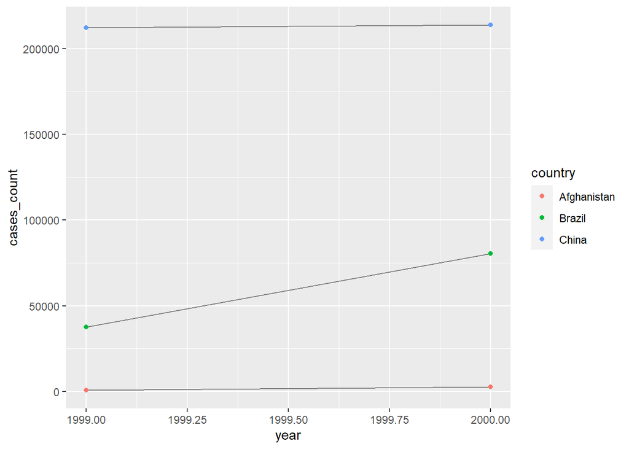

```r
ggplot(table2, aes(year, cases_count)) +
 geom_line(aes(group = country), color = "grey50") +
 geom_point(aes(color = country))
```

To use table2, I had to change the data in ggplot to table2 and also change the cases variable name because I changed it during my work.

# Chapter 9 (Pg. 156)

## Exercise 2

```r
table4a %>%
 gather(`1999`, `2000`, key = "year", value = "cases")
```

```
## # A tibble: 6 × 3
##   country     year   cases
##   <chr>       <chr>  <dbl>
## 1 Afghanistan 1999     745
## 2 Brazil      1999   37737
## 3 China       1999  212258
## 4 Afghanistan 2000    2666
## 5 Brazil      2000   80488
## 6 China       2000  213766
```

The reason the code given in the example failed was becasuse 1999 and 2000 were not put in backticks.

## Exercise 4

```r
preg <- tribble(
 ~pregnant, ~male, ~female,
 "yes", NA, 10,
 "no", 20, 12
)


gather(preg, key = "gender", value = "count", -pregnant)
```

```
## # A tibble: 4 × 3
##   pregnant gender count
##   <chr>    <chr>  <dbl>
## 1 yes      male      NA
## 2 no       male      20
## 3 yes      female    10
## 4 no       female    12
```

The variables are pregnant, gender, and count. By using gather, it makes the data set much easier to understand.

# Chapter 9 (Pgs. 160-161)

## Exercise 1

```r
tibble(x = c("a,b,c", "d,e", "f,g,i")) %>%
 separate(x, c("one", "two", "three"),fill = "left")
```

```
## # A tibble: 3 × 3
##   one   two   three
##   <chr> <chr> <chr>
## 1 a     b     c
## 2 <NA>  d     e
## 3 f     g     i
```

```r
tibble(x = c("a,b,c", "d,e,f,g", "h,i,j")) %>%
 separate(x, c("one", "two", "three"), sep = ",", extra = "merge")
```

```
## # A tibble: 3 × 3
##   one   two   three
##   <chr> <chr> <chr>
## 1 a     b     c
## 2 d     e     f,g
## 3 h     i     j
```

Fill shifted where the NA would be placed. By using “left”, it filled the missing value on the left.

Extra allowed me to control what happened when there were too many pieces from my separator.

## Exercise 2

```r
tibble(x = c("a,b,c", "d,e", "f,g,i")) %>%
 separate(x, c("one", "two", "three"), remove =FALSE)
```

```
## # A tibble: 3 × 4
##   x     one   two   three
##   <chr> <chr> <chr> <chr>
## 1 a,b,c a     b     c
## 2 d,e   d     e     <NA>
## 3 f,g,i f     g     i
```

## Exercise 2

```r
tidy_pets <- tibble::tribble(
  ~rank, ~pet_type, ~breed,
  1L,        NA,    "Boston Terrier",
  2L,        NA,    "Retrievers (Labrador)",
  3L,        NA,    "Retrievers (Golden)",
  4L,        NA,    "French Bulldogs",
  5L,        NA,    "Bulldogs",
  6L,     "Dog",    "Beagles",
  1L,        NA,    "Persian",
  2L,        NA,    "Maine Coon",
  3L,        NA,    "Ragdoll",
  4L,        NA,    "Exotic",
  5L,        NA,    "Siamese",
  6L,     "Cat",    "American Short"
)

tidy_pets
```

```
## # A tibble: 12 × 3
##     rank pet_type breed
##    <int> <chr>    <chr>
##  1     1 <NA>     Boston Terrier
##  2     2 <NA>     Retrievers (Labrador)
##  3     3 <NA>     Retrievers (Golden)
##  4     4 <NA>     French Bulldogs
##  5     5 <NA>     Bulldogs
##  6     6 Dog      Beagles
##  7     1 <NA>     Persian
##  8     2 <NA>     Maine Coon
##  9     3 <NA>     Ragdoll
## 10     4 <NA>     Exotic
## 11     5 <NA>     Siamese
## 12     6 Cat      American Short
```

```r
tidy_pets %>%
  fill(pet_type, .direction = "up")
```

```
## # A tibble: 12 × 3
##     rank pet_type breed
##    <int> <chr>    <chr>
##  1     1 Dog      Boston Terrier
##  2     2 Dog      Retrievers (Labrador)
##  3     3 Dog      Retrievers (Golden)
##  4     4 Dog      French Bulldogs
##  5     5 Dog      Bulldogs
##  6     6 Dog      Beagles
##  7     1 Cat      Persian
##  8     2 Cat      Maine Coon
##  9     3 Cat      Ragdoll
## 10     4 Cat      Exotic
## 11     5 Cat      Siamese
## 12     6 Cat      American Short
```

# Chapter 9 (Pg. 168)

## Exercise 2

```r
who.tidy <- who %>%
  gather(key = "key", value = "cases", new_sp_m014:newrel_f65, na.rm = TRUE) %>%
  mutate(key = str_replace(key, "newrel", "new_rel")) %>%
  separate(key, c("new", "type", "sexage"), sep = "_") %>%
  select(-new, -iso2, -iso3) %>%
  separate(sexage, c("sex", "age"), sep = 1)


who.tidy.nomutate <- who %>%
  gather(key = "key", value = "cases", new_sp_m014:newrel_f65, na.rm = TRUE) %>%
  separate(key, c("new", "type", "sexage"), sep = "_") %>%
  select(-new, -iso2, -iso3) %>%
  separate(sexage, c("sex", "age"), sep = 1)
who.tidy
```

```
## # A tibble: 76,046 × 6
##    country      year type  sex   age   cases
##    <chr>       <dbl> <chr> <chr> <chr> <dbl>
##  1 Afghanistan  1997 sp    m     014       0
##  2 Afghanistan  1998 sp    m     014      30
##  3 Afghanistan  1999 sp    m     014       8
##  4 Afghanistan  2000 sp    m     014      52
##  5 Afghanistan  2001 sp    m     014     129
##  6 Afghanistan  2002 sp    m     014      90
##  7 Afghanistan  2003 sp    m     014     127
##  8 Afghanistan  2004 sp    m     014     139
##  9 Afghanistan  2005 sp    m     014     151
## 10 Afghanistan  2006 sp    m     014     193
## # ℹ 76,036 more rows
```

```r
who.tidy.nomutate
```

```
## # A tibble: 76,046 × 6
##    country      year type  sex   age   cases
##    <chr>       <dbl> <chr> <chr> <chr> <dbl>
##  1 Afghanistan  1997 sp    m     014       0
##  2 Afghanistan  1998 sp    m     014      30
##  3 Afghanistan  1999 sp    m     014       8
##  4 Afghanistan  2000 sp    m     014      52
##  5 Afghanistan  2001 sp    m     014     129
##  6 Afghanistan  2002 sp    m     014      90
##  7 Afghanistan  2003 sp    m     014     127
##  8 Afghanistan  2004 sp    m     014     139
##  9 Afghanistan  2005 sp    m     014     151
## 10 Afghanistan  2006 sp    m     014     193
## # ℹ 76,036 more rows
```

## Exercise 3

```r
who
```

```
## # A tibble: 7,240 × 60
##    country  iso2  iso3   year new_sp_m014 new_sp_m1524 new_sp_m2534 new_sp_m3544
##    <chr>    <chr> <chr> <dbl>       <dbl>        <dbl>        <dbl>        <dbl>
##  1 Afghani… AF    AFG    1980          NA           NA           NA           NA
##  2 Afghani… AF    AFG    1981          NA           NA           NA           NA
##  3 Afghani… AF    AFG    1982          NA           NA           NA           NA
##  4 Afghani… AF    AFG    1983          NA           NA           NA           NA
##  5 Afghani… AF    AFG    1984          NA           NA           NA           NA
##  6 Afghani… AF    AFG    1985          NA           NA           NA           NA
##  7 Afghani… AF    AFG    1986          NA           NA           NA           NA
##  8 Afghani… AF    AFG    1987          NA           NA           NA           NA
##  9 Afghani… AF    AFG    1988          NA           NA           NA           NA
## 10 Afghani… AF    AFG    1989          NA           NA           NA           NA
## # ℹ 7,230 more rows
## # ℹ 52 more variables: new_sp_m4554 <dbl>, new_sp_m5564 <dbl>,
## #   new_sp_m65 <dbl>, new_sp_f014 <dbl>, new_sp_f1524 <dbl>,
## #   new_sp_f2534 <dbl>, new_sp_f3544 <dbl>, new_sp_f4554 <dbl>,
## #   new_sp_f5564 <dbl>, new_sp_f65 <dbl>, new_sn_m014 <dbl>,
## #   new_sn_m1524 <dbl>, new_sn_m2534 <dbl>, new_sn_m3544 <dbl>,
## #   new_sn_m4554 <dbl>, new_sn_m5564 <dbl>, new_sn_m65 <dbl>, …
```

```r
who.tidy
```

```
## # A tibble: 76,046 × 6
##    country      year type  sex   age   cases
##    <chr>       <dbl> <chr> <chr> <chr> <dbl>
##  1 Afghanistan  1997 sp    m     014       0
##  2 Afghanistan  1998 sp    m     014      30
##  3 Afghanistan  1999 sp    m     014       8
##  4 Afghanistan  2000 sp    m     014      52
##  5 Afghanistan  2001 sp    m     014     129
##  6 Afghanistan  2002 sp    m     014      90
##  7 Afghanistan  2003 sp    m     014     127
##  8 Afghanistan  2004 sp    m     014     139
##  9 Afghanistan  2005 sp    m     014     151
## 10 Afghanistan  2006 sp    m     014     193
## # ℹ 76,036 more rows
```

By showing both datasets, it becomes clear that iso2 and iso3 are redundant and could be dropped. The country is the easiest of the 3 naming systems to understand and keeping the others has no barring on the actual data.

## Exercise 4

```r
who.tidy.group <- who.tidy %>%
  group_by(country, year, sex) %>%
  summarize(total_cases = sum(cases)) %>%
  ungroup()
who.tidy.group
```

```
## # A tibble: 6,921 × 4
##    country      year sex   total_cases
##    <chr>       <dbl> <chr>       <dbl>
##  1 Afghanistan  1997 f             102
##  2 Afghanistan  1997 m              26
##  3 Afghanistan  1998 f            1207
##  4 Afghanistan  1998 m             571
##  5 Afghanistan  1999 f             517
##  6 Afghanistan  1999 m             228
##  7 Afghanistan  2000 f            1751
##  8 Afghanistan  2000 m             915
##  9 Afghanistan  2001 f            3062
## 10 Afghanistan  2001 m            1577
## # ℹ 6,911 more rows
```

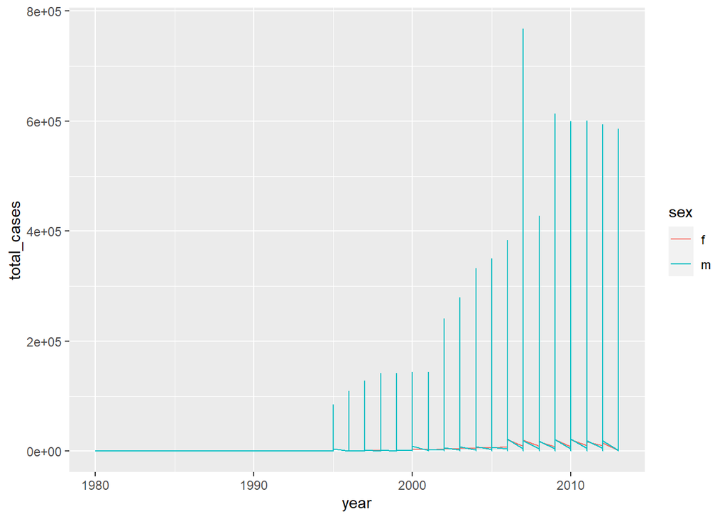

```r
ggplot(who.tidy.group) +
  geom_line(mapping = aes(x = year, y = total_cases, color = sex))
```